# Attrition Study - Case Study 2

Megan Ball

11/18/2020

# Executive Summary

A dataset containing 870 observations and a total of 35 variables was analyzed to look at what are the top factors leading to attrition, build a model to predict attrition, and build another model to predict the monthly income (salary). From this analysis, the top factors that lead to attrition are the specific job role, job level, monthly income, low work-life balance ratings, and low environment satisfaction. Additionally, a model was built with overall accuracy of 83%, sensitivity of 80%, and specificity of 83% at prediction attrition using a Naive-Bayes classifier. Another model to predict monthly income was also built and had a resulting RMSE of $1124.

# Load the Data

```r
df <- read_csv(here::here("data", "CaseStudy2-data.csv"))

# Check for missing values
tibble(variable = names(colSums(is.na(df))),
       missing = colSums(is.na(df))) %>%
  gt() %>%
  tab_header(title = "Missing Values in Data")
```

Missing Values in Data

| variable | missing |
| --- | --- |
| ID | 0 |
| Age | 0 |
| Attrition | 0 |
| BusinessTravel | 0 |
| DailyRate | 0 |
| Department | 0 |
| DistanceFromHome | 0 |
| Education | 0 |
| EducationField | 0 |
| EmployeeCount | 0 |
| EmployeeNumber | 0 |
| EnvironmentSatisfaction | 0 |
| Gender | 0 |
| HourlyRate | 0 |
| JobInvolvement | 0 |
| JobLevel | 0 |
| JobRole | 0 |
| JobSatisfaction | 0 |
| MaritalStatus | 0 |
| MonthlyIncome | 0 |
| MonthlyRate | 0 |
| NumCompaniesWorked | 0 |
| Over18 | 0 |
| OverTime | 0 |
| PercentSalaryHike | 0 |
| PerformanceRating | 0 |
| RelationshipSatisfaction | 0 |
| StandardHours | 0 |
| StockOptionLevel | 0 |
| TotalWorkingYears | 0 |
| TrainingTimesLastYear | 0 |
| WorkLifeBalance | 0 |
| YearsAtCompany | 0 |
| YearsInCurrentRole | 0 |
| YearsSinceLastPromotion | 0 |
| YearsWithCurrManager | 0 |

```r
#remove ID
df <- df %>% dplyr::select(-c(ID))
```

```r
#summarize data
summary(df)
```

```
##       Age         Attrition         BusinessTravel       DailyRate
##  Min.   :18.00   Length:870         Length:870         Min.   : 103.0
##  1st Qu.:30.00   Class :character   Class :character   1st Qu.: 472.5
##  Median :35.00   Mode  :character   Mode  :character   Median : 817.5
##  Mean   :36.83                                         Mean   : 815.2
##  3rd Qu.:43.00                                         3rd Qu.:1165.8
##  Max.   :60.00                                         Max.   :1499.0
##   Department        DistanceFromHome   Education     EducationField
##  Length:870         Min.   : 1.000   Min.   :1.000   Length:870
##  Class :character   1st Qu.: 2.000   1st Qu.:2.000   Class :character
##  Mode  :character   Median : 7.000   Median :3.000   Mode  :character
##                     Mean   : 9.339   Mean   :2.901
##                     3rd Qu.:14.000   3rd Qu.:4.000
##                     Max.   :29.000   Max.   :5.000
##  EmployeeCount EmployeeNumber   EnvironmentSatisfaction    Gender
##  Min.   :1     Min.   :   1.0   Min.   :1.000           Length:870
##  1st Qu.:1     1st Qu.: 477.2   1st Qu.:2.000           Class :character
##  Median :1     Median :1039.0   Median :3.000           Mode  :character
##  Mean   :1     Mean   :1029.8   Mean   :2.701
##  3rd Qu.:1     3rd Qu.:1561.5   3rd Qu.:4.000
##  Max.   :1     Max.   :2064.0   Max.   :4.000
##    HourlyRate     JobInvolvement     JobLevel       JobRole
##  Min.   : 30.00   Min.   :1.000   Min.   :1.000   Length:870
##  1st Qu.: 48.00   1st Qu.:2.000   1st Qu.:1.000   Class :character
##  Median : 66.00   Median :3.000   Median :2.000   Mode  :character
##  Mean   : 65.61   Mean   :2.723   Mean   :2.039
##  3rd Qu.: 83.00   3rd Qu.:3.000   3rd Qu.:3.000
##  Max.   :100.00   Max.   :4.000   Max.   :5.000
##  JobSatisfaction MaritalStatus      MonthlyIncome    MonthlyRate
##  Min.   :1.000   Length:870         Min.   : 1081   Min.   : 2094
##  1st Qu.:2.000   Class :character   1st Qu.: 2840   1st Qu.: 8092
##  Median :3.000   Mode  :character   Median : 4946   Median :14074
##  Mean   :2.709                      Mean   : 6390   Mean   :14326
##  3rd Qu.:4.000                      3rd Qu.: 8182   3rd Qu.:20456
##  Max.   :4.000                      Max.   :19999   Max.   :26997
##  NumCompaniesWorked    Over18            OverTime         PercentSalaryHike
##  Min.   :0.000      Length:870         Length:870         Min.   :11.0
##  1st Qu.:1.000      Class :character   Class :character   1st Qu.:12.0
##  Median :2.000      Mode  :character   Mode  :character   Median :14.0
##  Mean   :2.728                                            Mean   :15.2
```

[output cut: 8 more lines]

```
##  Max.   :4.000     Max.   :4.000            Max.   :80    Max.   :3.0000
##  TotalWorkingYears TrainingTimesLastYear WorkLifeBalance YearsAtCompany
##  Min.   : 0.00     Min.   :0.000         Min.   :1.000   Min.   : 0.000
##  1st Qu.: 6.00     1st Qu.:2.000         1st Qu.:2.000   1st Qu.: 3.000
##  Median :10.00     Median :3.000         Median :3.000   Median : 5.000
##  Mean   :11.05     Mean   :2.832         Mean   :2.782   Mean   : 6.962
##  3rd Qu.:15.00     3rd Qu.:3.000         3rd Qu.:3.000   3rd Qu.:10.000
##  Max.   :40.00     Max.   :6.000         Max.   :4.000   Max.   :40.000
##  YearsInCurrentRole YearsSinceLastPromotion YearsWithCurrManager
##  Min.   : 0.000     Min.   : 0.000          Min.   : 0.00
##  1st Qu.: 2.000     1st Qu.: 0.000          1st Qu.: 2.00
##  Median : 3.000     Median : 1.000          Median : 3.00
##  Mean   : 4.205     Mean   : 2.169          Mean   : 4.14
##  3rd Qu.: 7.000     3rd Qu.: 3.000          3rd Qu.: 7.00
##  Max.   :18.000     Max.   :15.000          Max.   :17.00
```

```r
#print(dfSummary(df, method = "browser"))
str(df)
```

```
## tibble [870 x 35] (S3: tbl_df/tbl/data.frame)
##  $ Age                     : num [1:870] 32 40 35 32 24 27 41 37 34 34 ...
##  $ Attrition               : chr [1:870] "No" "No" "No" "No" ...
##  $ BusinessTravel          : chr [1:870] "Travel_Rarely" "Travel_Rarely" "Travel_Frequently" "Travel_Rarely" ...
##  $ DailyRate               : num [1:870] 117 1308 200 801 567 ...
##  $ Department              : chr [1:870] "Sales" "Research & Development" "Research & Development" "Sales" ...
##  $ DistanceFromHome        : num [1:870] 13 14 18 1 2 10 5 10 10 10 ...
##  $ Education               : num [1:870] 4 3 2 4 1 2 5 4 4 4 ...
##  $ EducationField          : chr [1:870] "Life Sciences" "Medical" "Life Sciences" "Marketing" ...
##  $ EmployeeCount           : num [1:870] 1 1 1 1 1 1 1 1 1 1 ...
##  $ EmployeeNumber          : num [1:870] 859 1128 1412 2016 1646 ...
##  $ EnvironmentSatisfaction : num [1:870] 2 3 3 3 1 4 2 4 3 4 ...
##  $ Gender                  : chr [1:870] "Male" "Male" "Male" "Female" ...
##  $ HourlyRate              : num [1:870] 73 44 60 48 32 32 90 88 87 92 ...
##  $ JobInvolvement          : num [1:870] 3 2 3 3 3 3 4 2 3 2 ...
```

[output cut: 21 more lines]

```r
summary(df$StandardHours)
```

```
##    Min. 1st Qu.  Median    Mean 3rd Qu.    Max.
##      80      80      80      80      80      80
```

Comments on the data:  
- Investigate employee count- it has only one distinct value  
- Monthly income is skewed, as is expected with most income data  
- Over18 is all Y, so may remove the column as it is not useful data  
- Standard Hours is all 80, so may also remove this column  
- Investigate monthly income values, $19,999 seems pretty high for the max  
- There are no missing values in the data

```r
#update all characters to factors
df[sapply(df, is.character)] <- lapply(df[sapply(df, is.character)],
                                       as.factor)

str(df)
```

```
## tibble [870 x 35] (S3: tbl_df/tbl/data.frame)
##  $ Age                     : num [1:870] 32 40 35 32 24 27 41 37 34 34 ...
##  $ Attrition               : Factor w/ 2 levels "No","Yes": 1 1 1 1 1 1 1 1 1 1 ...
##  $ BusinessTravel          : Factor w/ 3 levels "Non-Travel","Travel_Frequently",..: 3 3 2 3 2 2 3 3 3 2 ...
##  $ DailyRate               : num [1:870] 117 1308 200 801 567 ...
##  $ Department              : Factor w/ 3 levels "Human Resources",..: 3 2 2 3 2 2 2 3 3 2 ...
##  $ DistanceFromHome        : num [1:870] 13 14 18 1 2 10 5 10 10 10 ...
##  $ Education               : num [1:870] 4 3 2 4 1 2 5 4 4 4 ...
##  $ EducationField          : Factor w/ 6 levels "Human Resources",..: 2 4 2 3 6 2 4 2 2 6 ...
##  $ EmployeeCount           : num [1:870] 1 1 1 1 1 1 1 1 1 1 ...
##  $ EmployeeNumber          : num [1:870] 859 1128 1412 2016 1646 ...
##  $ EnvironmentSatisfaction : num [1:870] 2 3 3 3 1 4 2 4 3 4 ...
##  $ Gender                  : Factor w/ 2 levels "Female","Male": 2 2 2 1 1 2 2 1 1 2 ...
##  $ HourlyRate              : num [1:870] 73 44 60 48 32 32 90 88 87 92 ...
##  $ JobInvolvement          : num [1:870] 3 2 3 3 3 3 4 2 3 2 ...
```

[output cut: 21 more lines]

Even though Education, EnvironmentSatisfaction, JobInvolvement, JobLevel, JobSatisfaction, PerformanceRating, StockOptionLevel, TrainingTimesLastYear, and WorkLifeBalance are all numeric, they all have distinct levels and therefore should be considered as factors and not continuous numeric variables.

```r
#update other groups to factors
cols <- c("Education", "EnvironmentSatisfaction", "JobInvolvement","JobLevel","JobSatisfaction","PerformanceRating","StockOptionLevel","TrainingTimesLastYear","WorkLifeBalance","NumCompaniesWorked","RelationshipSatisfaction")

df[cols] <- lapply(df[cols], factor)

str(df)
```

```
## tibble [870 x 35] (S3: tbl_df/tbl/data.frame)
##  $ Age                     : num [1:870] 32 40 35 32 24 27 41 37 34 34 ...
##  $ Attrition               : Factor w/ 2 levels "No","Yes": 1 1 1 1 1 1 1 1 1 1 ...
##  $ BusinessTravel          : Factor w/ 3 levels "Non-Travel","Travel_Frequently",..: 3 3 2 3 2 2 3 3 3 2 ...
##  $ DailyRate               : num [1:870] 117 1308 200 801 567 ...
##  $ Department              : Factor w/ 3 levels "Human Resources",..: 3 2 2 3 2 2 2 3 3 2 ...
##  $ DistanceFromHome        : num [1:870] 13 14 18 1 2 10 5 10 10 10 ...
##  $ Education               : Factor w/ 5 levels "1","2","3","4",..: 4 3 2 4 1 2 5 4 4 4 ...
##  $ EducationField          : Factor w/ 6 levels "Human Resources",..: 2 4 2 3 6 2 4 2 2 6 ...
##  $ EmployeeCount           : num [1:870] 1 1 1 1 1 1 1 1 1 1 ...
##  $ EmployeeNumber          : num [1:870] 859 1128 1412 2016 1646 ...
##  $ EnvironmentSatisfaction : Factor w/ 4 levels "1","2","3","4": 2 3 3 3 1 4 2 4 3 4 ...
##  $ Gender                  : Factor w/ 2 levels "Female","Male": 2 2 2 1 1 2 2 1 1 2 ...
##  $ HourlyRate              : num [1:870] 73 44 60 48 32 32 90 88 87 92 ...
##  $ JobInvolvement          : Factor w/ 4 levels "1","2","3","4": 3 2 3 3 3 3 4 2 3 2 ...
```

[output cut: 21 more lines]

```r
print(dfSummary(df, graph.magnif = 0.75), method = 'browser')
```

We actually want a few to be ordered factors as they are ratings.

```r
df$Education <- factor(df$Education, ordered = TRUE)
df$EnvironmentSatisfaction <- factor(df$EnvironmentSatisfaction, ordered = TRUE)
df$JobLevel <- factor(df$JobLevel, ordered = TRUE)
df$JobSatisfaction <- factor(df$JobSatisfaction, ordered = TRUE)
df$PerformanceRating <- factor(df$PerformanceRating, ordered = TRUE)
df$RelationshipSatisfaction <- factor(df$RelationshipSatisfaction, ordered = TRUE)
df$WorkLifeBalance <- factor(df$WorkLifeBalance, ordered = TRUE)

#str(df)
```

# Exploratory Data Analysis

[figure not shown]

```r
#set colors for graphs
cbPalette <- c("#56B4E9", "#009E73", "#F0E442", "#0072B2", "#D55E00", "#CC79A7","#999999", "#E69F00")

#check monthly income high values
df %>%
  ggplot(aes(x = JobRole, y = MonthlyIncome, fill = JobLevel)) +
  geom_boxplot() +
  ggtitle("Job Role & Income") +
  scale_fill_manual(values=cbPalette)
```

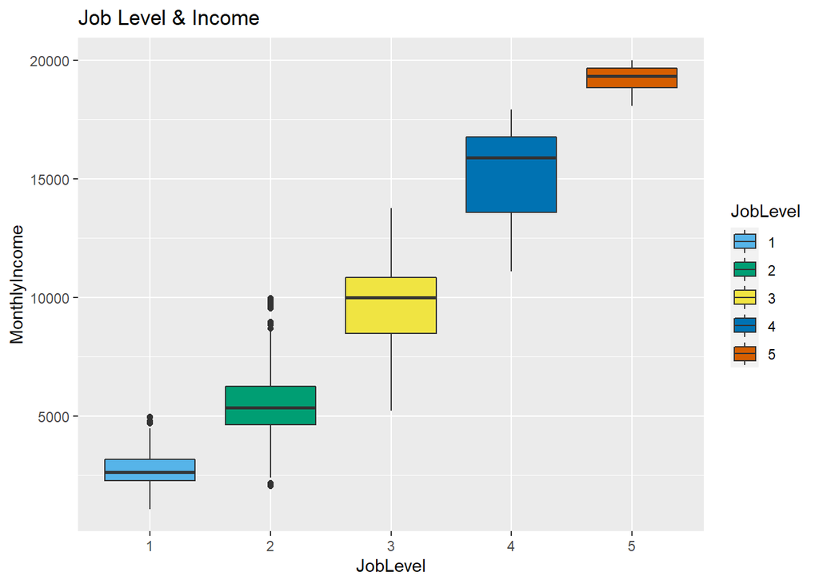

```r
df %>%
  ggplot(aes(x = JobLevel, y = MonthlyIncome, fill = JobLevel)) +
  geom_boxplot() +
  ggtitle("Job Level & Income") +
  scale_fill_manual(values=cbPalette)
```

Monthly income seems to align with job levels. The highest salaries are at job level of 4 & 5, so is probably not an anomaly.

```r
#remove unnecessary values, employee count, over18, and standard hours
df <- df %>% dplyr::select(-c(EmployeeCount, Over18, StandardHours, EmployeeNumber))
```

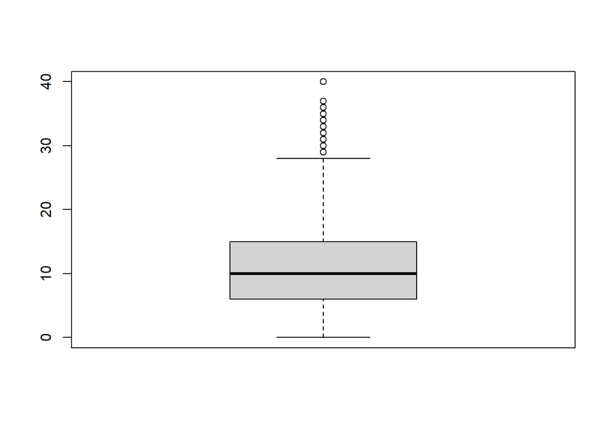

```r
#check if we need to limit total working years
boxplot(df$TotalWorkingYears)
```

Exclude all ‘outliers’ as we aren’t really interested in attrition rate for people that have been working > 30 years, since they are closer to retirement age generally than those working for< 30 years.

```r
df <- df %>% filter(TotalWorkingYears <= 30)
```

We are now down to 845 observations, but it removed some potentially influential outliers. It now limits our scope to employees working 30 or less years.

YearsSinceLastPromotion also looks like it might have some outliers, let’s check the boxplot.

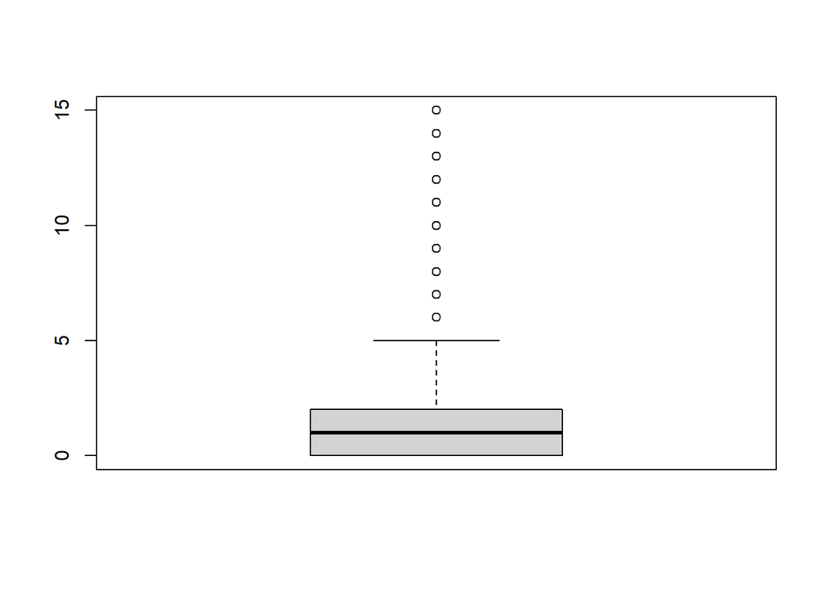

```r
boxplot(df$YearsSinceLastPromotion)
```

This seems to be an important variable in determining attrition, so let’s leave it in, but we do have quite a few outliers.

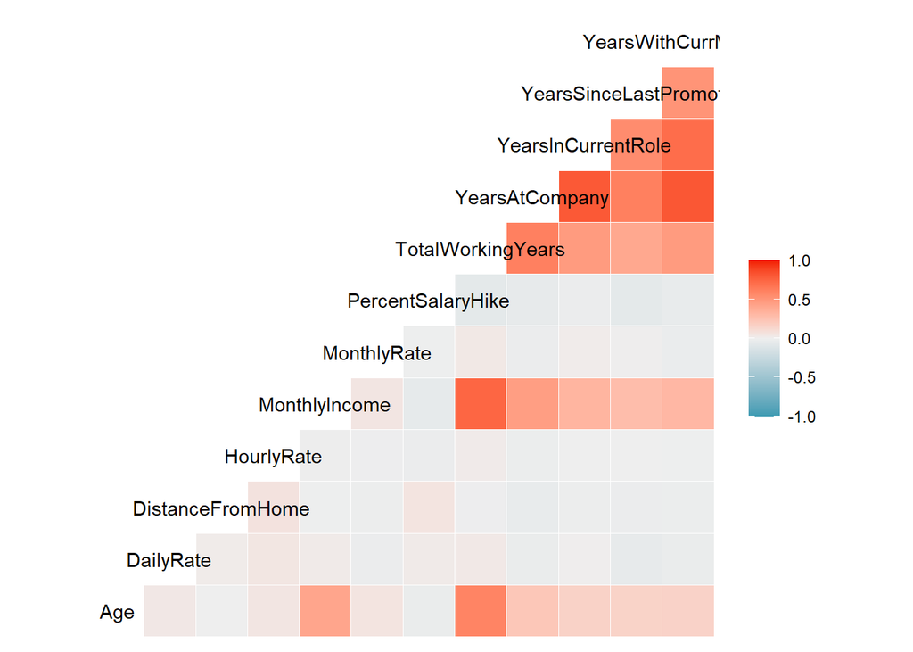

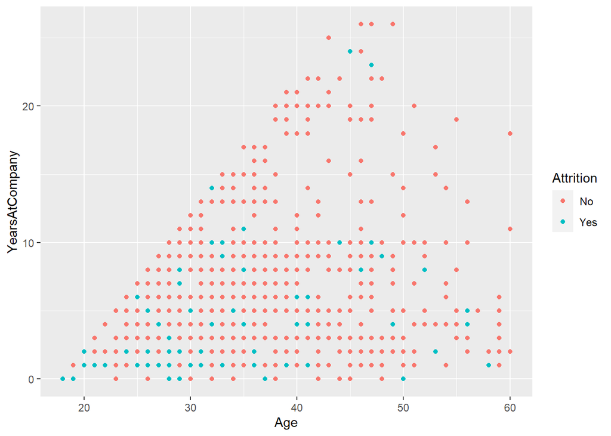

```r
#plot the highest correlation variables to investigate further

df %>% ggplot(aes(x= Age, y = YearsAtCompany, colour = Attrition)) +
  geom_point()
```

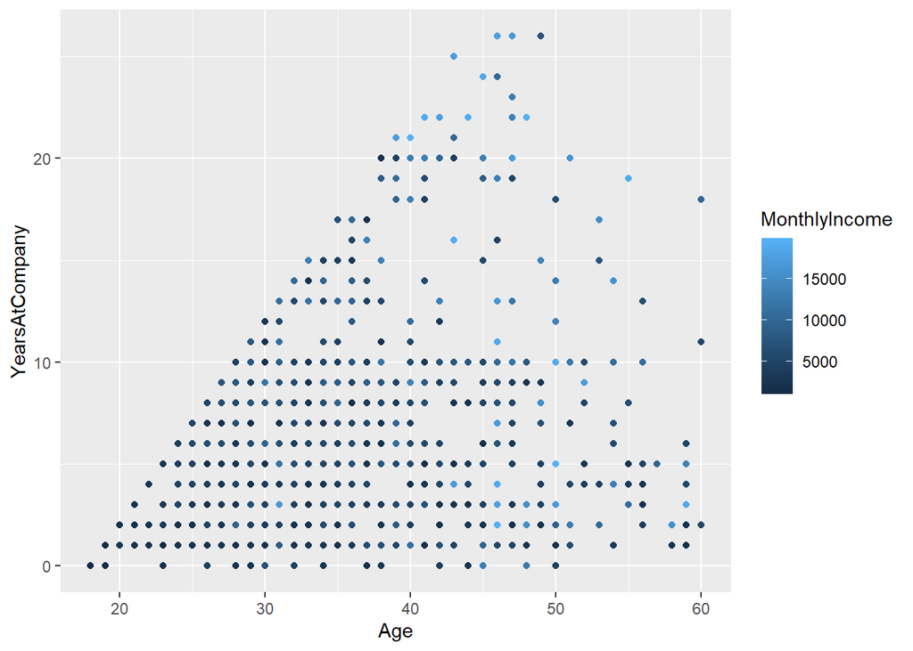

```r
df %>% ggplot(aes(x= Age, y = YearsAtCompany, colour = MonthlyIncome)) +
  geom_point()
```

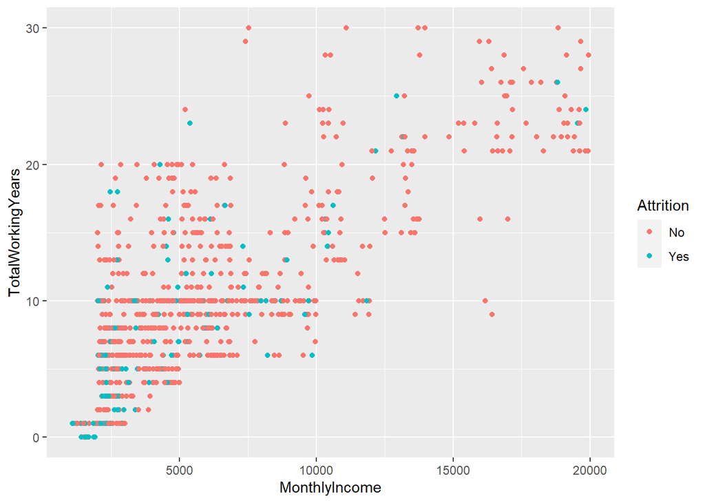

```r
df %>% ggplot(aes(x= MonthlyIncome, y = TotalWorkingYears, colour = Attrition)) +
  geom_point()
```

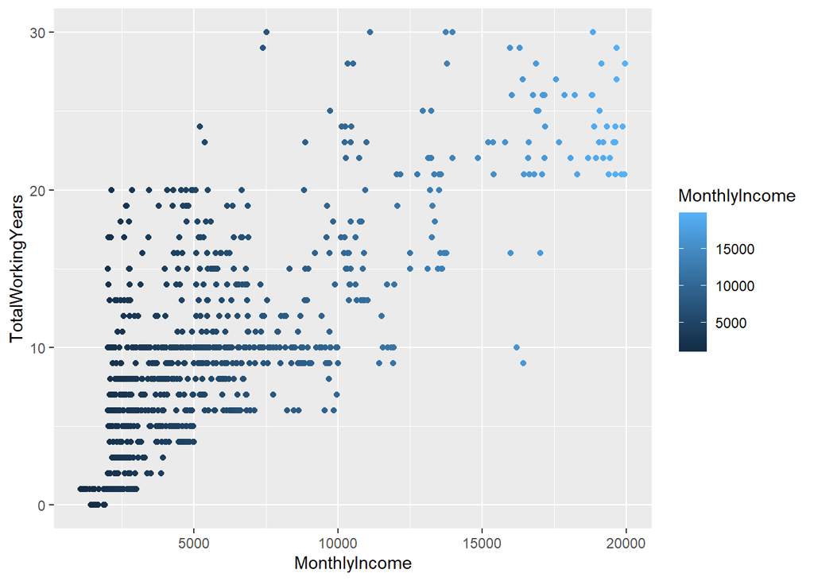

```r
df %>% ggplot(aes(x= MonthlyIncome, y = TotalWorkingYears, colour = MonthlyIncome)) +
  geom_point()
```

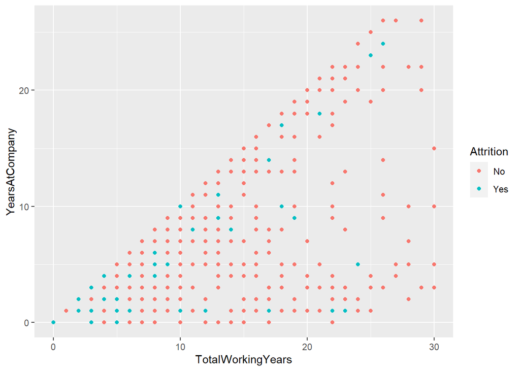

```r
df %>% ggplot(aes(x= TotalWorkingYears, y = YearsAtCompany, colour = Attrition)) +
  geom_point()
```

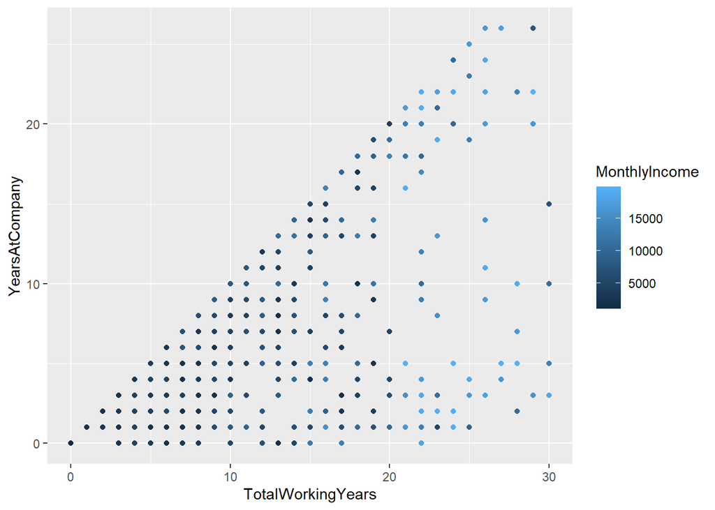

```r
df %>% ggplot(aes(x= TotalWorkingYears, y = YearsAtCompany, colour = MonthlyIncome)) +
  geom_point()
```

All of the data including years in the role, total working years, etc show high correlations as to be expected. However, these also seem to be valuable predictors in determining attrition and monthly income so do not want to remove them at this time.

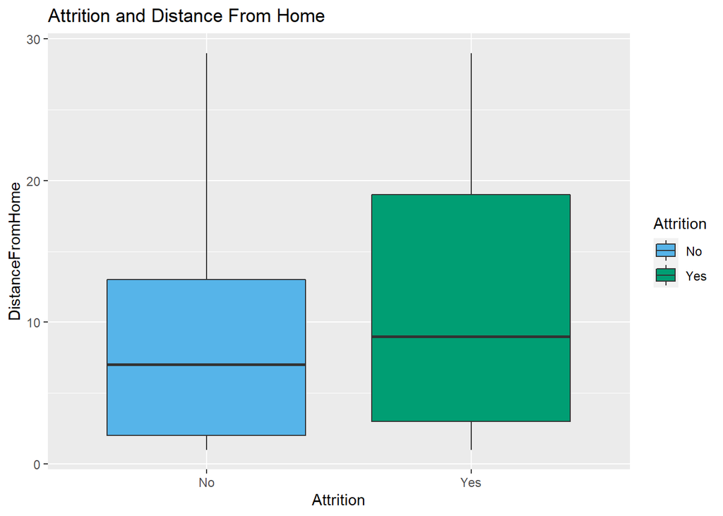

```r
#check distance from home

df %>%
  ggplot(aes(x = Attrition, y = DistanceFromHome, fill = Attrition)) +
  geom_boxplot() +
  ggtitle("Attrition and Distance From Home") +
  scale_fill_manual(values=cbPalette)
```

It looks like there could be higher attrition with farther home distances, but may not be significantly different. Perform t-test to check.

```r
t.test(DistanceFromHome ~ Attrition, data = df, mu = 0, conf.level = 0.95)
```

```
##
##  Welch Two Sample t-test
##
## data:  DistanceFromHome by Attrition
## t = -2.4537, df = 181.79, p-value = 0.01508
## alternative hypothesis: true difference in means is not equal to 0
## 95 percent confidence interval:
##  -3.5602816 -0.3864997
## sample estimates:
##  mean in group No mean in group Yes
##          8.990113         10.963504
```

With a p-value of 0.015, we do reject the null hypothesis that the true difference in means is equal to 0 for both groups. The mean for the group that is “yes” for attrition is 10.96 miles, whereas the mean for the group that is “no” is 8.99 miles. This does not seem to be a practically significant difference.

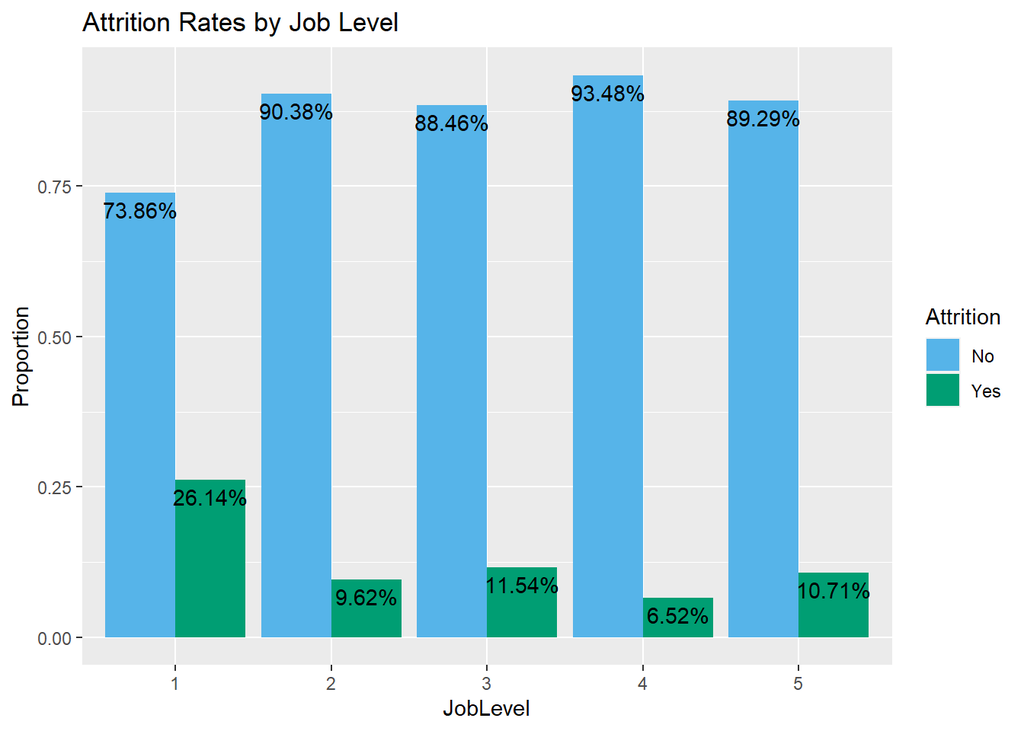

```r
#look at attrition by job level and job role
df %>%
    group_by(JobLevel) %>%
    count(Attrition) %>%
    mutate(prop = n/sum(n)) %>%
    ggplot(aes(x = JobLevel, y = prop)) +
    geom_col(aes(fill = Attrition), position = "dodge") +
    geom_text(aes(label = scales::percent(prop),
                  y = prop,
                  group = Attrition),
              position = position_dodge(width = 0.9),
              vjust = 1.5) +
  ggtitle("Attrition Rates by Job Level") +
  ylab("Proportion") +
  scale_fill_manual(values=cbPalette)
```

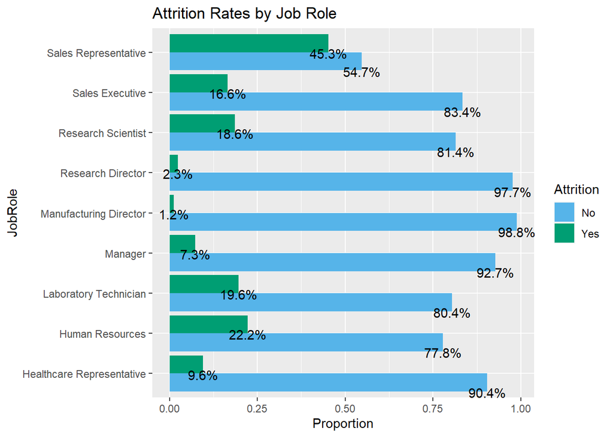

```r
ggsave("joblevel.png")

df %>%
    group_by(JobRole) %>%
    count(Attrition) %>%
    mutate(prop = n/sum(n)) %>%
    ggplot(aes(x = JobRole, y = prop)) +
    geom_col(aes(fill = Attrition), position = "dodge") +
    geom_text(aes(label = scales::percent(prop),
                  y = prop,
                  group = Attrition),
              position = position_dodge(width = 0.9),
              vjust = 1.5) +
  coord_flip() +
  ggtitle("Attrition Rates by Job Role") +
  ylab("Proportion") +
  scale_fill_manual(values=cbPalette)
```

```r
ggsave("jobrole.png")
```

As expected, the earlier you are in your career, the higher the attrition rate. It is interesting to note that job level 4 has the lowest attrition rate of all the levels at only 6.52%.

Sales representatives have by far the highest attrition rate at almost half, 45.3%. Research Directors and Manufacturing Directors are lowest at 2.3% and 1.2% respectively.

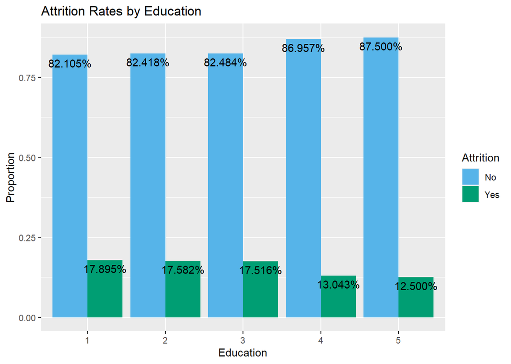

```r
#Check attrition and salary by education level
df %>%
    group_by(Education) %>%
    count(Attrition) %>%
    mutate(prop = n/sum(n)) %>%
    ggplot(aes(x = Education, y = prop)) +
    geom_col(aes(fill = Attrition), position = "dodge") +
    geom_text(aes(label = scales::percent(prop),
                  y = prop,
                  group = Attrition),
              position = position_dodge(width = 0.9),
              vjust = 1.5) +
  ggtitle("Attrition Rates by Education") +
  ylab("Proportion") +
  scale_fill_manual(values=cbPalette)
```

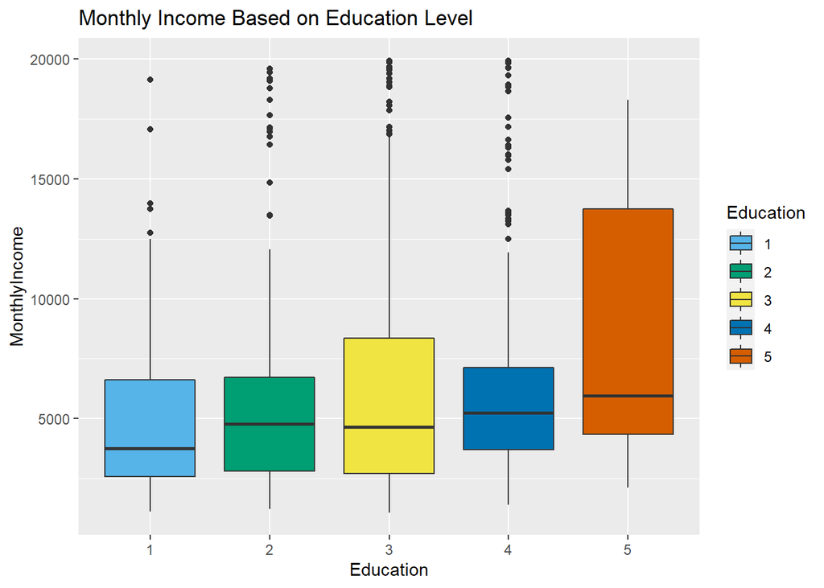

```r
df %>% ggplot(aes(x = Education, y = MonthlyIncome, fill = Education)) +
  geom_boxplot() +
  ggtitle("Monthly Income Based on Education Level") +
  scale_fill_manual(values=cbPalette)
```

Attrition seems to be independent of education level, although it decreases slightly with post-graduate levels. Monthly Income also does not change significantly until you reach the post-graduate level as well.

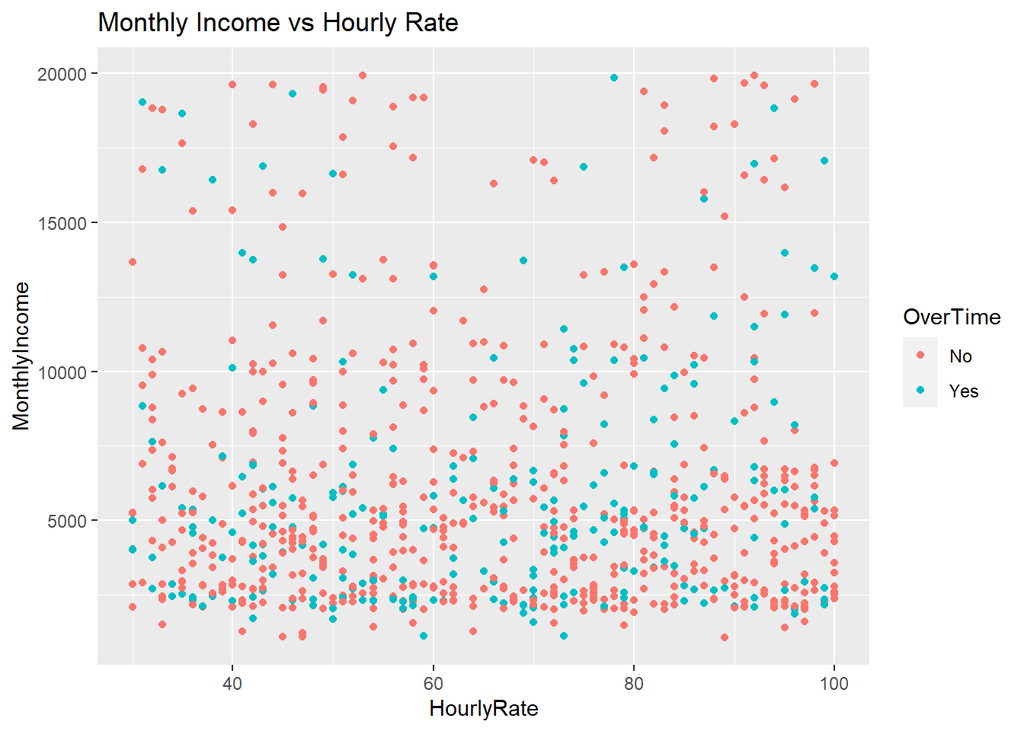

```r
#plot hourly rate vs monthly income - corrplot didn't show correlation which is odd

df %>%
  ggplot(aes(x = HourlyRate, y = MonthlyIncome, color = OverTime)) +
  geom_point() +
  ggtitle("Monthly Income vs Hourly Rate")
```

This relationship is very odd. You would expect the monthly income to increase the same as hourly rate, given that our data reported standard hours as 80 for each data row. Suspect this if salaried or not. Keep it in for now, may turn out to be useful.

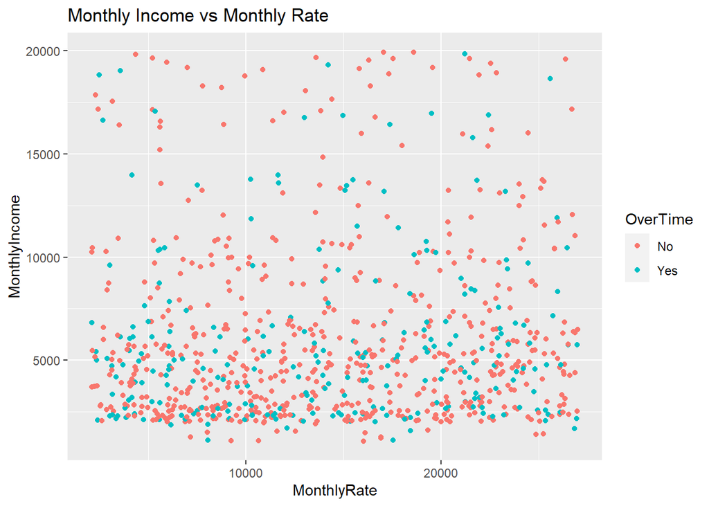

```r
#check monthly rate and monthly income

df %>%
  ggplot(aes(x = MonthlyRate, y = MonthlyIncome, color = OverTime)) +
  geom_point() +
  ggtitle("Monthly Income vs Monthly Rate")
```

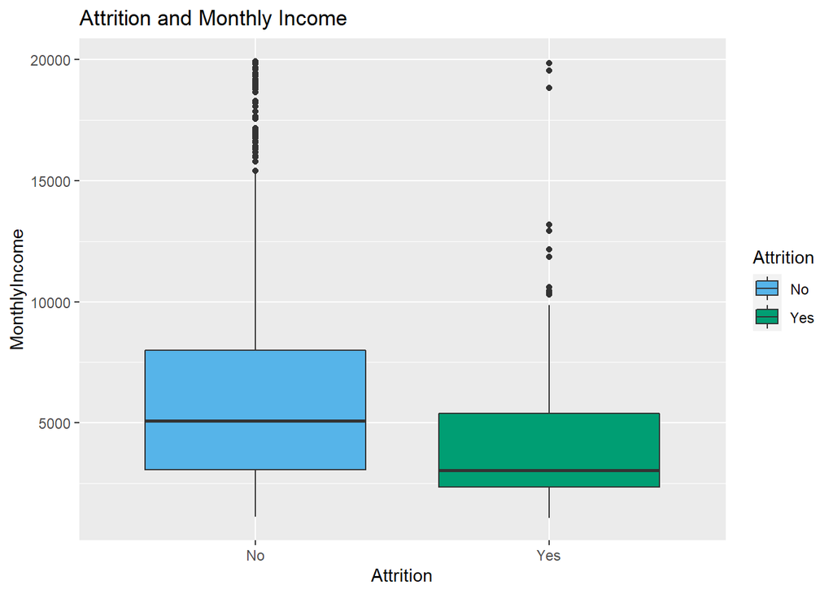

```r
#check attrition based on monthly income
df %>%
  ggplot(aes(x = Attrition, y = MonthlyIncome, fill = Attrition)) +
  geom_boxplot() +
  ggtitle("Attrition and Monthly Income") +
  scale_fill_manual(values=cbPalette)
```

```r
ggsave("income.png")
```

Lower monthly incomes are associated with more attrition.

```r
#check the outliers in the "yes" group
df %>% filter(Attrition == "Yes") %>% top_n(3, MonthlyIncome)
```

```
## # A tibble: 3 x 31
##     Age Attrition BusinessTravel DailyRate Department DistanceFromHome Education
##   <dbl> <fct>     <fct>              <dbl> <fct>                 <dbl> <ord>
## 1    55 Yes       Travel_Rarely        725 Research ~                2 3
## 2    41 Yes       Travel_Rarely       1360 Research ~               12 3
## 3    45 Yes       Travel_Rarely       1449 Sales                     2 3
## # ... with 24 more variables: EducationField <fct>,
## #   EnvironmentSatisfaction <ord>, Gender <fct>, HourlyRate <dbl>,
## #   JobInvolvement <fct>, JobLevel <ord>, JobRole <fct>, JobSatisfaction <ord>,
## #   MaritalStatus <fct>, MonthlyIncome <dbl>, MonthlyRate <dbl>,
## #   NumCompaniesWorked <fct>, OverTime <fct>, PercentSalaryHike <dbl>,
## #   PerformanceRating <ord>, RelationshipSatisfaction <ord>,
## #   StockOptionLevel <fct>, TotalWorkingYears <dbl>,
## #   TrainingTimesLastYear <fct>, WorkLifeBalance <ord>, YearsAtCompany <dbl>,
## #   YearsInCurrentRole <dbl>, YearsSinceLastPromotion <dbl>,
## #   YearsWithCurrManager <dbl>
```

```r
#Run t-test to check if statistically significant

t.test(MonthlyIncome ~ Attrition, data = df, mu = 0, conf.level = 0.95)
```

```
##
##  Welch Two Sample t-test
##
## data:  MonthlyIncome by Attrition
## t = 5.2876, df = 225.04, p-value = 2.929e-07
## alternative hypothesis: true difference in means is not equal to 0
## 95 percent confidence interval:
##  1141.939 2498.720
## sample estimates:
##  mean in group No mean in group Yes
##          6396.278          4575.949
```

With a p-value of < 0.001, we reject the null hypothesis that the true difference in means of monthly income are equal for those that quit and those that do not. Therefore we can conclude monthly income has some influence on attrition rates.

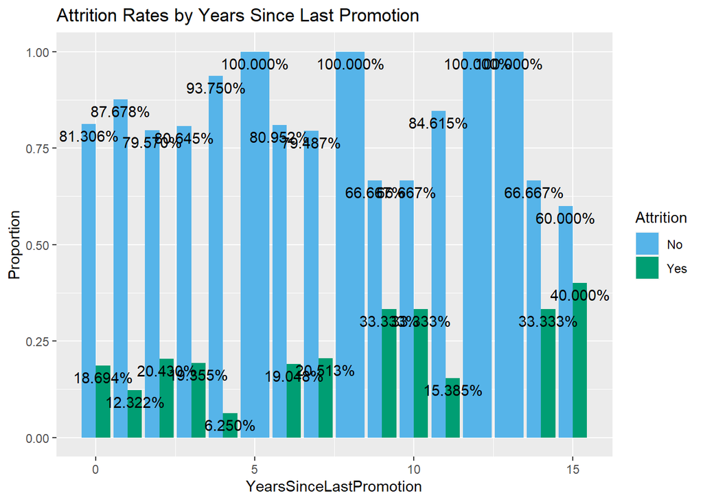

```r
#look at attrition by years since last promotion
df %>%
    group_by(YearsSinceLastPromotion) %>%
    count(Attrition) %>%
    mutate(prop = n/sum(n)) %>%
    ggplot(aes(x = YearsSinceLastPromotion, y = prop)) +
    geom_col(aes(fill = Attrition), position = "dodge") +
    geom_text(aes(label = scales::percent(prop),
                  y = prop,
                  group = Attrition),
              position = position_dodge(width = 0.9),
              vjust = 1.5) +
  ggtitle("Attrition Rates by Years Since Last Promotion") +
  ylab("Proportion") +
  scale_fill_manual(values=cbPalette)
```

There does not seem to be a single conclusion that can be made for attrition based on years since last promotion.

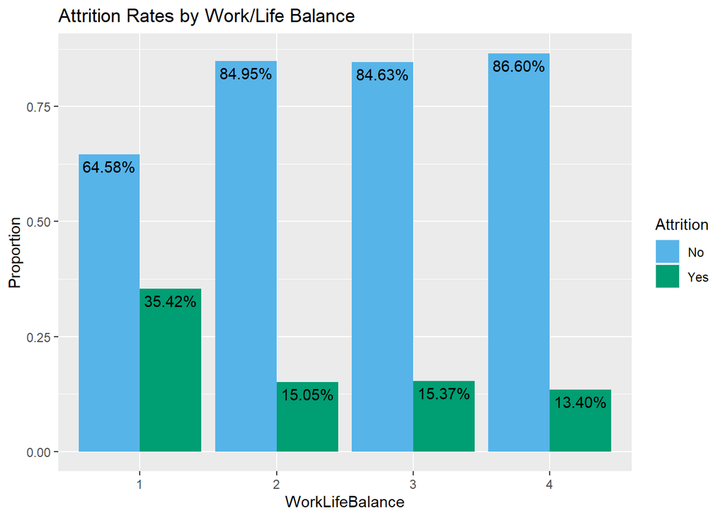

```r
#look at attrition by work/life balance
df %>%
    group_by(WorkLifeBalance) %>%
    count(Attrition) %>%
    mutate(prop = n/sum(n)) %>%
    ggplot(aes(x = WorkLifeBalance, y = prop)) +
    geom_col(aes(fill = Attrition), position = "dodge") +
    geom_text(aes(label = scales::percent(prop),
                  y = prop,
                  group = Attrition),
              position = position_dodge(width = 0.9),
              vjust = 1.5) +
  ggtitle("Attrition Rates by Work/Life Balance") +
  ylab("Proportion") +
  scale_fill_manual(values=cbPalette)
```

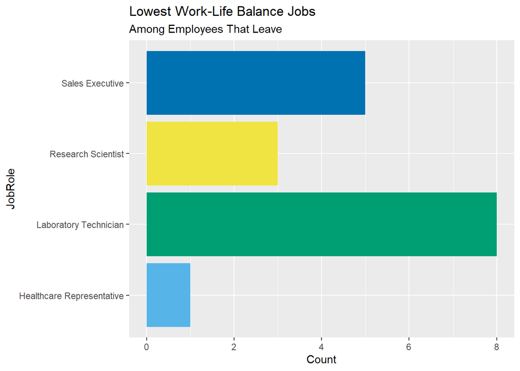

```r
ggsave("overall.png")

#job roles for lowest work/life balance ratings + attrition = "yes"
pie <- df %>%
  filter(WorkLifeBalance == "1" & Attrition == "Yes")

pie %>% group_by(JobRole) %>%
  count(JobRole) %>%
  ggplot(aes(x = JobRole, y = n, fill = JobRole)) +
  geom_bar(stat = "identity") +
  labs(title="Lowest Work-Life Balance Jobs",
       subtitle = "Among Employees That Leave")  +
  ylab("Count") +
  scale_fill_manual(values=cbPalette) +
  theme(legend.position = "none") +
  coord_flip()
```

```r
ggsave("worklife.png")

#how many of each job role overall
df %>%
    group_by(JobRole) %>%
    count(JobRole)
```

```
## # A tibble: 9 x 2
## # Groups:   JobRole [9]
##   JobRole                       n
##   <fct>                     <int>
## 1 Healthcare Representative    73
## 2 Human Resources              27
## 3 Laboratory Technician       153
## 4 Manager                      41
## 5 Manufacturing Director       84
## 6 Research Director            43
## 7 Research Scientist          172
## 8 Sales Executive             199
## 9 Sales Representative         53
```

Assuming that 1 is bad work/life balance, it would make sense to see higher attrition rates for this variable.

Let’s check for business travel.

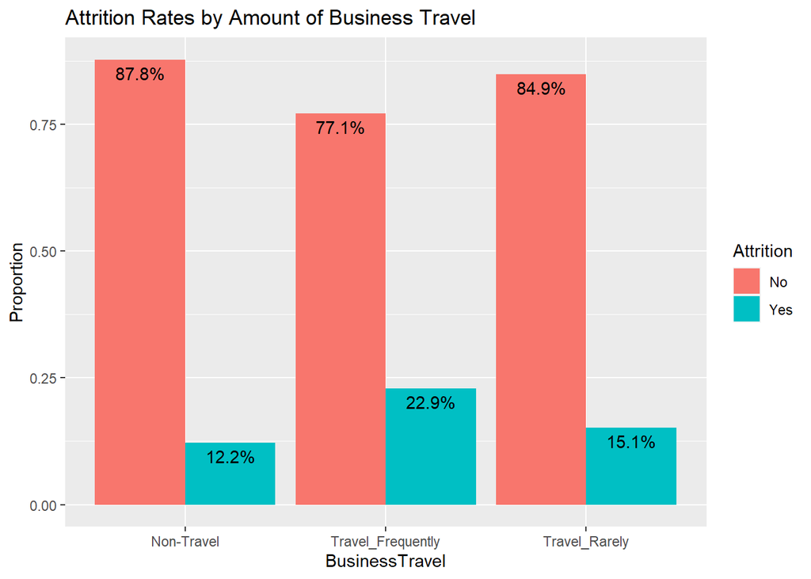

```r
df %>%
    group_by(BusinessTravel) %>%
    count(Attrition) %>%
    mutate(prop = n/sum(n)) %>%
    ggplot(aes(x = BusinessTravel, y = prop)) +
    geom_col(aes(fill = Attrition), position = "dodge") +
    geom_text(aes(label = scales::percent(prop),
                  y = prop,
                  group = Attrition),
              position = position_dodge(width = 0.9),
              vjust = 1.5) +
  ggtitle("Attrition Rates by Amount of Business Travel") +
  ylab("Proportion")
```

No strong conclusions to make about business travel.

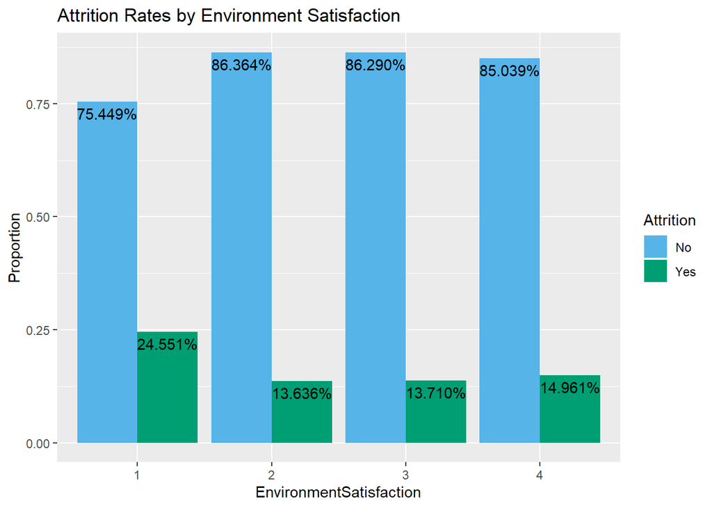

```r
#environment satisfaction
df %>%
    group_by(EnvironmentSatisfaction) %>%
    count(Attrition) %>%
    mutate(prop = n/sum(n)) %>%
    ggplot(aes(x = EnvironmentSatisfaction, y = prop)) +
    geom_col(aes(fill = Attrition), position = "dodge") +
    geom_text(aes(label = scales::percent(prop),
                  y = prop,
                  group = Attrition),
              position = position_dodge(width = 0.9),
              vjust = 1.5) +
  ggtitle("Attrition Rates by Environment Satisfaction") +
  ylab("Proportion") +
  scale_fill_manual(values=cbPalette)
```

```r
ggsave("env.png")
```

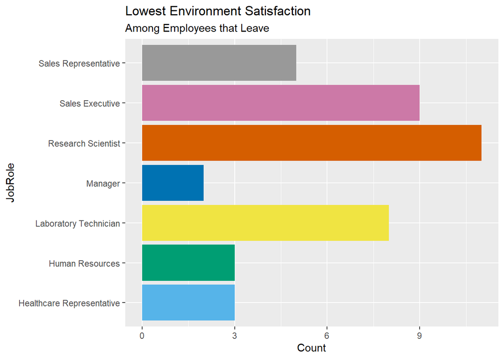

```r
pie2 <- df %>%
  filter(EnvironmentSatisfaction == "1" & Attrition == "Yes")

pie2 %>% group_by(JobRole) %>%
  count(JobRole) %>%
  ggplot(aes(x = JobRole, y = n, fill = JobRole)) +
  geom_bar(stat = "identity") +
  labs(title="Lowest Environment Satisfaction",
       subtitle = "Among Employees that Leave")  +
  ylab("Count") +
  scale_fill_manual(values=cbPalette) +
  theme(legend.position = "none") +
  coord_flip()
```

```r
ggsave("environment.png")
```

Before going into our model building, the top variables that seem to indicate attrition are: - Work/Life Balance - Job Level - Monthly Income - Job Role - Environment Satisfaction

# Standardize Data for KNN

```r
#create standardized data set to run specifically for knn

df.std <- df %>%
    mutate_if(is.numeric, scale)
```

# Create Test/Train Splits

```r
#data set is pretty small at only 870 obs, complete 70/30 splits and get reasonable amount of YES in each set

# set random seed
set.seed(1)
# create the training partition that is 70% of total obs
inTraining <- createDataPartition(df$Attrition, p=0.7, list=FALSE)
# create training/testing dataset
trainSet <- df[inTraining,]
testSet <- df[-inTraining,]
# verify number of obs
nrow(trainSet)
```

```
## [1] 592
```

```r
nrow(testSet)
```

```
## [1] 253
```

```r
head(trainSet)
```

```
## # A tibble: 6 x 31
##     Age Attrition BusinessTravel DailyRate Department DistanceFromHome Education
##   <dbl> <fct>     <fct>              <dbl> <fct>                 <dbl> <ord>
## 1    32 No        Travel_Rarely        117 Sales                    13 4
## 2    40 No        Travel_Rarely       1308 Research ~               14 3
## 3    35 No        Travel_Freque~       200 Research ~               18 2
## 4    32 No        Travel_Rarely        801 Sales                     1 4
## 5    24 No        Travel_Freque~       567 Research ~                2 1
## 6    27 No        Travel_Freque~       294 Research ~               10 2
## # ... with 24 more variables: EducationField <fct>,
## #   EnvironmentSatisfaction <ord>, Gender <fct>, HourlyRate <dbl>,
## #   JobInvolvement <fct>, JobLevel <ord>, JobRole <fct>, JobSatisfaction <ord>,
## #   MaritalStatus <fct>, MonthlyIncome <dbl>, MonthlyRate <dbl>,
## #   NumCompaniesWorked <fct>, OverTime <fct>, PercentSalaryHike <dbl>,
## #   PerformanceRating <ord>, RelationshipSatisfaction <ord>,
## #   StockOptionLevel <fct>, TotalWorkingYears <dbl>,
## #   TrainingTimesLastYear <fct>, WorkLifeBalance <ord>, YearsAtCompany <dbl>,
## #   YearsInCurrentRole <dbl>, YearsSinceLastPromotion <dbl>,
## #   YearsWithCurrManager <dbl>
```

```r
head(testSet)
```

```
## # A tibble: 6 x 31
##     Age Attrition BusinessTravel DailyRate Department DistanceFromHome Education
##   <dbl> <fct>     <fct>              <dbl> <fct>                 <dbl> <ord>
## 1    34 No        Travel_Freque~       653 Research ~               10 4
## 2    28 No        Non-Travel           280 Human Res~                1 2
## 3    35 No        Travel_Rarely        950 Research ~                7 3
## 4    30 No        Travel_Rarely        202 Sales                     2 1
## 5    32 No        Travel_Rarely        498 Research ~                3 4
## 6    43 No        Travel_Freque~      1001 Research ~                9 5
## # ... with 24 more variables: EducationField <fct>,
## #   EnvironmentSatisfaction <ord>, Gender <fct>, HourlyRate <dbl>,
## #   JobInvolvement <fct>, JobLevel <ord>, JobRole <fct>, JobSatisfaction <ord>,
## #   MaritalStatus <fct>, MonthlyIncome <dbl>, MonthlyRate <dbl>,
## #   NumCompaniesWorked <fct>, OverTime <fct>, PercentSalaryHike <dbl>,
## #   PerformanceRating <ord>, RelationshipSatisfaction <ord>,
## #   StockOptionLevel <fct>, TotalWorkingYears <dbl>,
## #   TrainingTimesLastYear <fct>, WorkLifeBalance <ord>, YearsAtCompany <dbl>,
## #   YearsInCurrentRole <dbl>, YearsSinceLastPromotion <dbl>,
## #   YearsWithCurrManager <dbl>
```

```r
#check how many "Yes" attrition in train & test
summary(trainSet$Attrition)
```

```
##  No Yes
## 496  96
```

```r
summary(testSet$Attrition)
```

```
##  No Yes
## 212  41
```

# Test/Train for KNN only

```r
# set random seed
set.seed(1)
# create the training partition that is 70% of total obs
inTraining <- createDataPartition(df.std$Attrition, p=0.7, list=FALSE)
# create training/testing dataset
trainSet.knn <- df.std[inTraining,]
testSet.knn <- df.std[-inTraining,]
# verify number of obs
nrow(trainSet.knn)
```

```
## [1] 592
```

```r
nrow(testSet.knn)
```

```
## [1] 253
```

```r
#check how many "Yes" attrition in train & test
summary(trainSet.knn$Attrition)
```

```
##  No Yes
## 496  96
```

```r
summary(testSet.knn$Attrition)
```

```
##  No Yes
## 212  41
```

# KNN Model

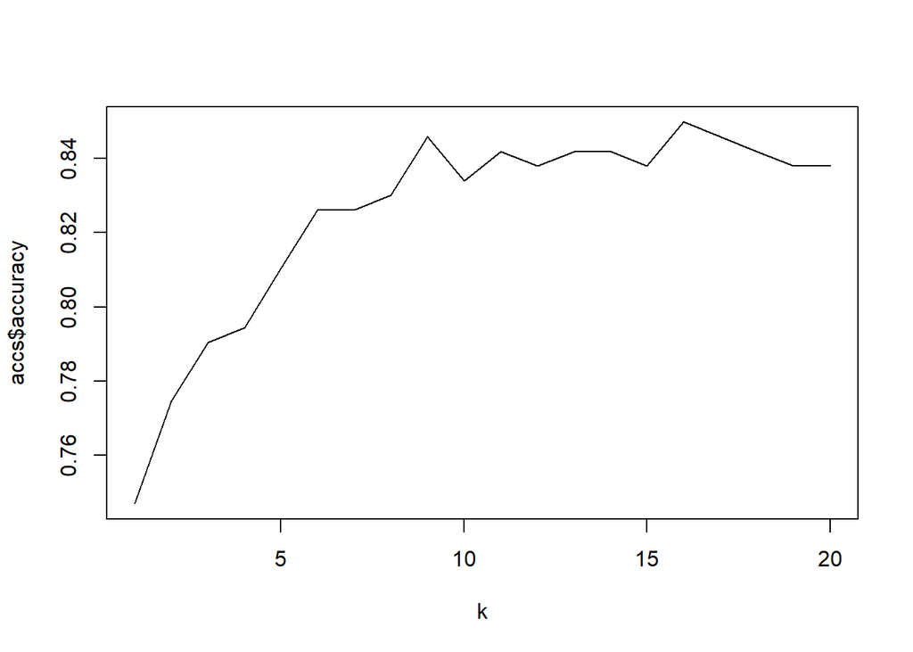

```r
#loop to find optimal k for sensitivity

accs <- data.frame(accuracy = numeric(20), k = numeric(20))
sens <- data.frame(sensitivity = numeric(20), k = numeric(20))

#make numeric only train and test as knn can only run on continuous variables
trainNum <- trainSet.knn[ , sapply(trainSet.knn, is.numeric)]
#add back Attrition
trainNum <- cbind(trainNum,trainSet.knn$Attrition)
names(trainNum)[names(trainNum)=="trainSet.knn$Attrition"] <- "Attrition"

testNum <- testSet.knn[ , sapply(testSet.knn, is.numeric)]
#add back Attrition
testNum <- cbind(testNum,testSet.knn$Attrition)
names(testNum)[names(testNum)=="testSet.knn$Attrition"] <- "Attrition"

for(i in 1:20)
{
  classifications <- knn(trainNum[,1:12],testNum[,1:12],trainNum$Attrition,prob = TRUE, k = i)
  table(testNum$Attrition,classifications)
  CM <- confusionMatrix(table(testNum$Attrition,classifications), positive = "Yes")
  accs$accuracy[i] = CM$overall[1]
  accs$k[i] = i
  sens$sensitivity[i] = CM$byClass[1]
  sens$k[i] = i
}

plot(accs$k,accs$accuracy, type = "l", xlab = "k")
```

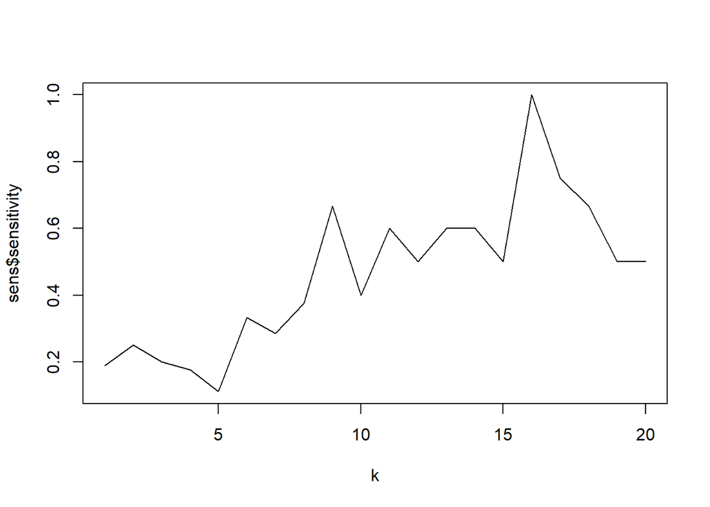

```r
plot(sens$k,sens$sensitivity, type = "l", xlab = "k")
```

```r
accs
```

```
##     accuracy  k
## 1  0.7470356  1
## 2  0.7747036  2
## 3  0.7905138  3
## 4  0.7944664  4
## 5  0.8102767  5
## 6  0.8260870  6
## 7  0.8260870  7
## 8  0.8300395  8
## 9  0.8458498  9
## 10 0.8339921 10
## 11 0.8418972 11
## 12 0.8379447 12
## 13 0.8418972 13
## 14 0.8418972 14
## 15 0.8379447 15
## 16 0.8498024 16
## 17 0.8458498 17
## 18 0.8418972 18
## 19 0.8379447 19
## 20 0.8379447 20
```

```r
sens
```

```
##    sensitivity  k
## 1    0.1891892  1
## 2    0.2500000  2
## 3    0.2000000  3
## 4    0.1764706  4
## 5    0.1111111  5
## 6    0.3333333  6
## 7    0.2857143  7
## 8    0.3750000  8
## 9    0.6666667  9
## 10   0.4000000 10
## 11   0.6000000 11
## 12   0.5000000 12
## 13   0.6000000 13
## 14   0.6000000 14
## 15   0.5000000 15
## 16   1.0000000 16
## 17   0.7500000 17
## 18   0.6666667 18
## 19   0.5000000 19
## 20   0.5000000 20
```

```r
which.max(sens$sensitivity)
```

```
## [1] 16
```

# Run KNN

```r
#k=17 had good accuracy and sensitivity, run model with k=17 and check sensitivity and specificity on test set

classifications <- knn(trainNum[,1:12],testNum[,1:12],trainNum$Attrition,prob = TRUE, k = 17)
table(testNum$Attrition,classifications)
```

```
##      classifications
##        No Yes
##   No  211   1
##   Yes  38   3
```

```r
CM <- confusionMatrix(table(testNum$Attrition,classifications), positive = "Yes")
CM
```

```
## Confusion Matrix and Statistics
##
##      classifications
##        No Yes
##   No  211   1
##   Yes  38   3
##
##                Accuracy : 0.8458
##                  95% CI : (0.7954, 0.888)
##     No Information Rate : 0.9842
##     P-Value [Acc > NIR] : 1
##
##                   Kappa : 0.1076
##
##  Mcnemar's Test P-Value : 8.185e-09
##
##             Sensitivity : 0.75000
##             Specificity : 0.84739
##          Pos Pred Value : 0.07317
##          Neg Pred Value : 0.99528
##              Prevalence : 0.01581
##          Detection Rate : 0.01186
##    Detection Prevalence : 0.16206
##       Balanced Accuracy : 0.79869
##
##        'Positive' Class : Yes
##
```

We have overall accuracy at 84%, sensitivity at 75%, and specificity at 85%. Overall that’s not too bad, but it only predicted “Yes” 3 times out of 41 actual yeses.

Let’s run with only the top suspected numeric variables.

```r
classifications_top <- kNN(Attrition ~ MonthlyIncome + TotalWorkingYears + YearsAtCompany,trainNum,testNum,prob = TRUE, k = 5)
#table(testNum$Attrition,classifications_top)
CM_top <- confusionMatrix(table(testNum$Attrition,classifications_top), positive = "Yes")
CM_top
```

```
## Confusion Matrix and Statistics
##
##      classifications_top
##        No Yes
##   No  204   8
##   Yes  40   1
##
##                Accuracy : 0.8103
##                  95% CI : (0.7564, 0.8567)
##     No Information Rate : 0.9644
##     P-Value [Acc > NIR] : 1
##
##                   Kappa : -0.0195
##
##  Mcnemar's Test P-Value : 7.66e-06
##
##             Sensitivity : 0.111111
##             Specificity : 0.836066
##          Pos Pred Value : 0.024390
##          Neg Pred Value : 0.962264
##              Prevalence : 0.035573
##          Detection Rate : 0.003953
##    Detection Prevalence : 0.162055
##       Balanced Accuracy : 0.473588
##
##        'Positive' Class : Yes
##
```

# KNN with caret

```r
## KNN with 10x cross validation repeated 5x
fitControl <- trainControl(method="repeatedcv",
                           repeats = 5,
                           number=10,
                           classProbs=T,
                           summaryFunction=twoClassSummary)

set.seed(1234)
## evaluate on train set based on area under the ROC (AUC)
KNN_caret <- train(Attrition ~.,
             data=trainNum,
             method="knn",
             trControl=fitControl,
             tuneGrid=expand.grid(.k=c(1,3,5,7,9,11,15,17)),
             metric = "ROC")

KNN_caret
```

```
## k-Nearest Neighbors
##
## 592 samples
##  12 predictor
##   2 classes: 'No', 'Yes'
##
## No pre-processing
## Resampling: Cross-Validated (10 fold, repeated 5 times)
## Summary of sample sizes: 532, 533, 533, 533, 533, 533, ...
## Resampling results across tuning parameters:
##
##   k   ROC        Sens       Spec
##    1  0.5120512  0.8545469  0.16955556
##    3  0.5658356  0.9400163  0.12377778
##    5  0.5880110  0.9548816  0.10800000
##    7  0.5969038  0.9673878  0.07666667
##    9  0.6071814  0.9738531  0.05933333
##   11  0.6134052  0.9794857  0.04955556
##   15  0.6298600  0.9923510  0.02466667
##   17  0.6345838  0.9927510  0.01600000
##
## ROC was used to select the optimal model using the largest value.
## The final value used for the model was k = 17.
```

Because we suspect the top contributing factors to be factors and not numeric variables, KNN is probably not best model (but it is odd it had the exact same performance with just a few numeric variables). Let’s move on to Naive Bayes which will use both numeric and factors.

# Naive Bayes Classifier

```r
#run model on all variables
NB1 = naiveBayes(Attrition~ .,data = trainSet)
summary(NB1)
```

```
##           Length Class  Mode
## apriori    2     table  numeric
## tables    30     -none- list
## levels     2     -none- character
## isnumeric 30     -none- logical
## call       4     -none- call
```

```r
#predict on the test set
pred1 <- predict(NB1,testSet, type = "raw")

#confusion matrix
confusionMatrix(table(predict(NB1,testSet),testSet$Attrition), positive = "Yes")
```

```
## Confusion Matrix and Statistics
##
##
##        No Yes
##   No  183  11
##   Yes  29  30
##
##                Accuracy : 0.8419
##                  95% CI : (0.791, 0.8846)
##     No Information Rate : 0.8379
##     P-Value [Acc > NIR] : 0.47365
##
##                   Kappa : 0.5054
##
##  Mcnemar's Test P-Value : 0.00719
##
##             Sensitivity : 0.7317
##             Specificity : 0.8632
##          Pos Pred Value : 0.5085
##          Neg Pred Value : 0.9433
##              Prevalence : 0.1621
##          Detection Rate : 0.1186
##    Detection Prevalence : 0.2332
##       Balanced Accuracy : 0.7975
##
##        'Positive' Class : Yes
##
```

```r
summary(testSet$Attrition)
```

```
##  No Yes
## 212  41
```

```r
summary(trainSet$Attrition)
```

```
##  No Yes
## 496  96
```

Our Naive Bayes classifier performs really good in comparison to best KNN model. Overall accuracy is 84% with specificity at 86% and sensitivity at 73%. Of our total 41 yeses, it predicted 30 accurately.

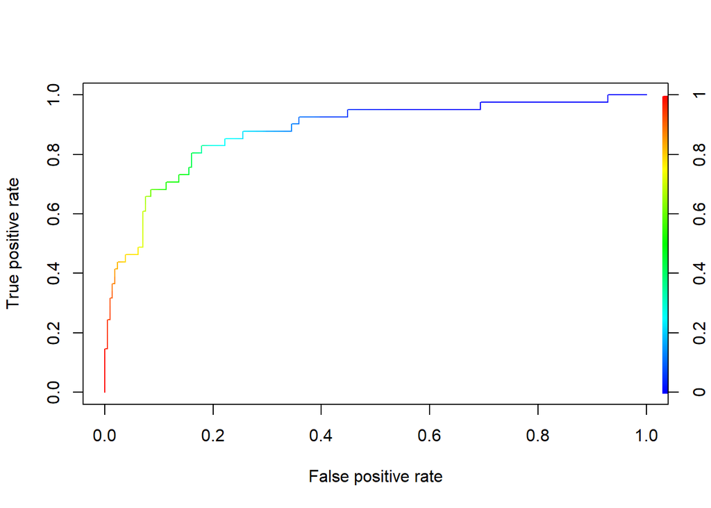

```r
#check for different cut off for better performance
preds_nb <- as.data.frame(pred1)

preds_nb1 <- prediction(preds_nb[,2],testSet$Attrition)
roc.perf_nb = performance(preds_nb1, measure = "tpr", x.measure = "fpr")
auc.train_nb <- performance(preds_nb1, measure = "auc")
auc.train_nb <- auc.train_nb@y.values
plot(roc.perf_nb, colorize = TRUE)
```

```r
#check metrics when cut-off = 0.4 instead of 0.5
cutoff<-0.4
class.nb<-factor(ifelse(pred1[,2]>cutoff,"Yes","No"))

confusionMatrix(class.nb,testSet$Attrition, positive = "Yes")
```

```
## Confusion Matrix and Statistics
##
##           Reference
## Prediction  No Yes
##        No  177   8
##        Yes  35  33
##
##                Accuracy : 0.83
##                  95% CI : (0.778, 0.8742)
##     No Information Rate : 0.8379
##     P-Value [Acc > NIR] : 0.6708
##
##                   Kappa : 0.5055
##
##  Mcnemar's Test P-Value : 7.341e-05
##
##             Sensitivity : 0.8049
##             Specificity : 0.8349
##          Pos Pred Value : 0.4853
##          Neg Pred Value : 0.9568
##              Prevalence : 0.1621
##          Detection Rate : 0.1304
##    Detection Prevalence : 0.2688
##       Balanced Accuracy : 0.8199
##
##        'Positive' Class : Yes
##
```

Metrics improve slightly with cutoff at 0.4 instead of 0.5, with sens/spec both around 80%. This is our best model so far.

```r
#run model on top variables from EDA
NB2 = naiveBayes(Attrition~ WorkLifeBalance + MonthlyIncome + JobLevel + JobRole + EnvironmentSatisfaction,data = trainSet)
summary(NB2)
```

```
##           Length Class  Mode
## apriori   2      table  numeric
## tables    5      -none- list
## levels    2      -none- character
## isnumeric 5      -none- logical
## call      4      -none- call
```

```r
#predict on the test set
pred2 <- predict(NB2,testSet, type="raw")

#confusion matrix
confusionMatrix(table(predict(NB2,testSet),testSet$Attrition), positive = "Yes")
```

```
## Confusion Matrix and Statistics
##
##
##        No Yes
##   No  197  27
##   Yes  15  14
##
##                Accuracy : 0.834
##                  95% CI : (0.7823, 0.8777)
##     No Information Rate : 0.8379
##     P-Value [Acc > NIR] : 0.60787
##
##                   Kappa : 0.3069
##
##  Mcnemar's Test P-Value : 0.08963
##
##             Sensitivity : 0.34146
##             Specificity : 0.92925
##          Pos Pred Value : 0.48276
##          Neg Pred Value : 0.87946
##              Prevalence : 0.16206
##          Detection Rate : 0.05534
##    Detection Prevalence : 0.11462
##       Balanced Accuracy : 0.63535
##
##        'Positive' Class : Yes
##
```

When we subset to what we suspected were the top variables, our sensitivity decreases to 34%.

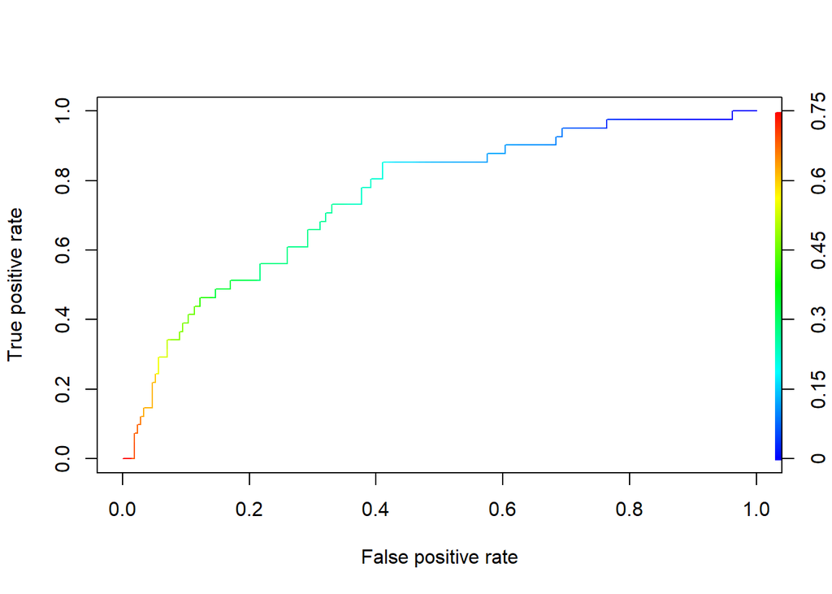

```r
#check for different cut off for better performance
preds_nb2 <- as.data.frame(pred2)

preds_nb2 <- prediction(preds_nb2[,2],testSet$Attrition)
roc.perf_nb2 = performance(preds_nb2, measure = "tpr", x.measure = "fpr")
auc.train_nb2 <- performance(preds_nb2, measure = "auc")
auc.train_nb2 <- auc.train_nb2@y.values
plot(roc.perf_nb2, colorize = TRUE)
```

Maybe these are not in fact the top variables, as our sensitivity drops off with just these variables and our AUC goes down.

Let’s try a Random Forest classifier which will also tell us variable importance.

# Random Forest

```r
fitRF
```

```
## Random Forest
##
## 592 samples
##  30 predictor
##   2 classes: 'No', 'Yes'
##
## No pre-processing
## Resampling: Cross-Validated (10 fold, repeated 3 times)
## Summary of sample sizes: 532, 532, 532, 534, 534, 532, ...
## Resampling results across tuning parameters:
##
##   mtry  ROC        Sens       Spec
##    10   0.7648054  0.9905850  0.1359259
##    50   0.7470977  0.9771293  0.2374074
##   100   0.7406971  0.9643537  0.2470370
##   250   0.7417333  0.9650204  0.2537037
##   500   0.7416757  0.9656599  0.2470370
##
## ROC was used to select the optimal model using the largest value.
## The final value used for the model was mtry = 10.
```

```r
varImp(fitRF)
```

```
## rf variable importance
##
##   only 20 most important variables shown (out of 75)
##
##                            Overall
## MonthlyIncome               100.00
## OverTimeYes                  95.52
## Age                          78.44
## DistanceFromHome             70.57
## DailyRate                    67.27
## MonthlyRate                  66.43
## TotalWorkingYears            61.94
## YearsAtCompany               61.71
## HourlyRate                   60.65
## PercentSalaryHike            58.80
## YearsWithCurrManager         43.28
## YearsInCurrentRole           42.74
## YearsSinceLastPromotion      42.46
## JobSatisfaction.L            34.58
## EnvironmentSatisfaction.L    30.70
## RelationshipSatisfaction.L   29.22
## WorkLifeBalance.L            27.50
## StockOptionLevel1            26.36
## JobSatisfaction.C            25.82
## Education.L                  24.92
```

Re-run Naive Bayes with top 10 variables per Random Forest model.

```r
#Naive Bayes
NB3 = naiveBayes(Attrition~ MonthlyIncome + Age + TotalWorkingYears + DailyRate + OverTime + MonthlyRate + HourlyRate + PercentSalaryHike + DistanceFromHome + YearsAtCompany,data = trainSet)
summary(NB3)
```

```
##           Length Class  Mode
## apriori    2     table  numeric
## tables    10     -none- list
## levels     2     -none- character
## isnumeric 10     -none- logical
## call       4     -none- call
```

```r
#predict on the test set
pred3 <- predict(NB3,testSet,type="raw")

#confusion matrix
confusionMatrix(table(predict(NB3,testSet),testSet$Attrition), positive = "Yes")
```

```
## Confusion Matrix and Statistics
##
##
##        No Yes
##   No  202  29
##   Yes  10  12
##
##                Accuracy : 0.8458
##                  95% CI : (0.7954, 0.888)
##     No Information Rate : 0.8379
##     P-Value [Acc > NIR] : 0.406047
##
##                   Kappa : 0.3019
##
##  Mcnemar's Test P-Value : 0.003948
##
##             Sensitivity : 0.29268
##             Specificity : 0.95283
##          Pos Pred Value : 0.54545
##          Neg Pred Value : 0.87446
##              Prevalence : 0.16206
##          Detection Rate : 0.04743
##    Detection Prevalence : 0.08696
##       Balanced Accuracy : 0.62276
##
##        'Positive' Class : Yes
##
```

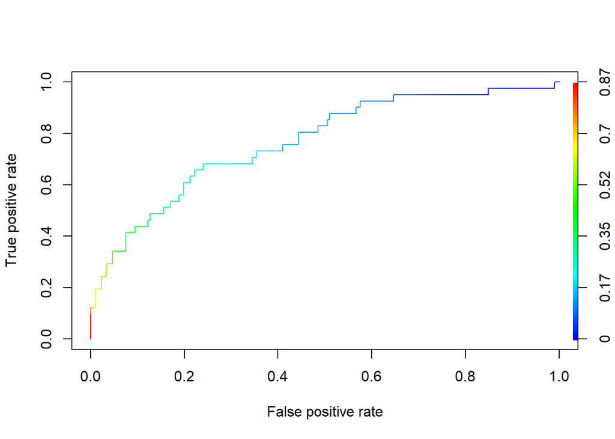

```r
#check for different cut off for better performance
preds_nb3 <- as.data.frame(pred3)

preds_nb3 <- prediction(preds_nb3[,2],testSet$Attrition)
roc.perf_nb3 = performance(preds_nb3, measure = "tpr", x.measure = "fpr")
auc.train_nb3 <- performance(preds_nb3, measure = "auc")
auc.train_nb3 <- auc.train_nb3@y.values
plot(roc.perf_nb3, colorize = TRUE)
```

Let’s stick with our best model for classification: Naive Bayes with all variables and cutoff of 0.4.

Let’s move on to creating a linear regression model to predict monthly income.